# Air Quality Station

Anna Madison Burns

7/7/2020

# Overview

# Materials Needed

# Wiring

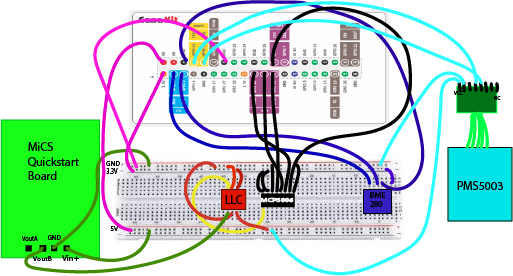

Wiring Diagram

## PMS5003 Wiring

## BME280 Wiring

## LLC Wiring

## ADC Wiring

## MiCS-2714 Wiring

## Breadboard Wiring

# Code

## Settings

Now that the station is assembled, we need to prepare our Raspberry Pi to be able to receive and process the signals from our sensors. To do so, there are several settings we need to change.

Our sensors use several different communication methods with the Pi, which is fortunate because it allows us to run all of them at the same time! The following instructions will help you enable communication with the BME280 (I2C), PMS5003 (Serial), and MiCS-2714 (SPI).

1. Enter the Raspberry Pi’s configuration page by opening the shell and typing

```python
sudo raspi-config
```

which will take you to a menu with several options listed.

2. Select option 5, “Interfacing Options.”
3. Within this page, enable the following portals by selecting them and then indicating “Yes,” that you do want them to run:
- I2C
- SPI
4. We now need to enable serial communication. Within the same menu, select Serial.
5. A window will pop up asking, “would you like a login shell to be accessible over serial?”, and the answer is NO.
6. Next, a window will pop up asking, “Would you like the serial port hardware to be enabled?”, this time say YES, and exit the window.
7. Once you have enabled these options, you can exit the screen and begin installing the necessary packages. It may ask you to reboot you Pi, in which case do so before moving on.

## Packages Needed

Before we can use our code, there are several packages that need to be downloaded. To do so, enter your Raspberry Pi’s shell and enter the following commands.

First, it is essential that you make sure your Pi is up-to-date, so that you can get the latest versions of each package. Do this with the following two commands:

```python
sudo apt-get update
sudo apt-get upgrade
```

## MiCS-2714 Packages

The MiCS-2714 sensor code operates with a github package that controls the MCP3008 (the analog to digital convertor that allows the Pi to read our sensor’s signals). To install these packages, run each of the lines of the following code within your Pi’s shell:

```python
sudo apt-get install build-essential python-dev python-smbus git
cd ~
git clone https://github.com/adafruit/Adafruit_Python_MCP3008.git
cd Adafruit_Python_MCP3008
sudo python setup.py install
cd ~
```

## BME280 Packages

Our BME280 also operates with an Adafruit package on Github, which can be accessed with the following commands within the Pi shell:

```python
pip3 install adafruit-circuitpython-bme280
pip3 install --upgrade adafruit_blinka
```

These are all the packages we need to run our code, so now you can import the code and get your station running!

## Air Quality Station Code

The following code will output values to a csv file entitled “airquality_data.csv”, with readings for: NO2 levels in ppm; PM1, PM2.5, and PM10 levels in standard and environmental units; temperature, humidity, air pressure, and altitude.

To use this code, copy and paste it into a python shell within your Pi (either Nano, Thonny, or IDLE) and run the code per your chosen shell’s commands.

```python
# Import packages (which sensor uses which package is noted)
import spidev # MiCS-2714
import os # MiCS-2714
import serial # PMS5003
from collections import OrderedDict # PMS5003
import board # BME280
import busio # BME280
import adafruit_bme280 # BME280
import csv # All
import time # All

# MiCS-2714 Code
spi = spidev.SpiDev()
spi.open(0,0)
spi.max_speed_hz=1000000

def ReadChannel(channel):
  adc = spi.xfer2([1,(8+channel)<<4,0])
  data = ((adc[1]&3) << 8) + adc[2]
  return data

def ConvertVolts(data,places):
  volts = (data * 3.3) / float(1023)
  volts = round(volts,places)
  return volts

def ConvertNO2(data,places):
  NO2 = ((data * 10.05)/float(1023))+0.05
  NO2 = round(NO2,places)
  return NO2

NO2_channel = 0

# PMS5003 Code
class Sensor():
  def __init__(self, tty = '/dev/ttyS0'):
    self.tty = tty

  def open(self):
    self.serial = serial.Serial(self.tty, baudrate = 9600)

  def close(self):
    self.serial.close()

  def read_bytes(self, data, idx, size = 2):
    return int("".join(data[idx : idx + size]), 16)

  def read(self):
    data = self.serial.read(32)
    data = ["{:02X}".format(d) for d in data]

    if data[0] != '42' or data[1] != '4D':
      return None

    res = OrderedDict()
    res['pm1_cf'] = self.read_bytes(data, 4)
    res['pm25_cf'] = self.read_bytes(data, 6)
    res['pm10_cf'] = self.read_bytes(data, 8)
    res['pm1'] = self.read_bytes(data, 10)
    res['pm25'] = self.read_bytes(data, 12)
    res['pm10'] = self.read_bytes(data, 14)
    return res

# BME280 Code
i2c = busio.I2C(board.SCL, board.SDA)
bme280 = adafruit_bme280.Adafruit_BME280_I2C(i2c)
bme280.sea_level_pressure = 1013.25

# CSV Code
def  write_to_csv():
        if __name__ == "__main__":
                with open('/home/pi/airquality_data.csv', mode='a') as csv_file:
                        csv_writer = csv.writer(csv_file)
                        csv_writer.writerow([NO2,data,bme280.temperature, bme280.humidity, bme280.pressure, bme280.altitude])
                with open('/home/pi/airquality_data.csv', mode='r') as csv_file:
                        csv_reader = csv.reader(csv_file)
                        for row in csv_reader:
                                print(row)

# Command
if __name__ == "__main__":
  while True:
    # MiCS-2714 output
    NO2_level = ReadChannel(NO2_channel)
    NO2_volts = ConvertVolts(NO2_level,2)
    NO2       = ConvertNO2(NO2_level,2)
    # PMS5003 output
    sensor = Sensor()
    sensor.open()
    data = sensor.read()
    sensor.close()
    # Write to csv, sleep for 10 seconds
    write_to_csv()
    time.sleep(10)
```